# Project- J comp

## Dataset Used

slope (type: int) - the slope of the peak exercise ST segment, an electrocardiography read out indicating quality of blood flow to the heart – Value 1: upsloping – Value 2: flat – Value 3: downsloping

thal (type: categorical) - results of thallium stress test measuring blood flow to the heart, with possible – 1: normal – 2: fixed defect – 3: reversable defect

trestbps (type: int) - resting blood pressure

cp (type: int): chest pain type (4 values) – Value 1: typical angina – Value 2: atypical angina – Value 3: non-anginal pain  
– Value 4: asymptomatic

fbs (type: binary) - fasting blood sugar > 120 mg/dl

restecg (type: int) - resting electrocardiographic results (values 0,1,2)

oldpeak (type: float) - oldpeak = ST depression induced by exercise relative to rest, a measure of abnormality in electrocardiograms

sex (type: binary) - 0: female, 1: male

age (type: int) - age in years

exang: exercise_induced_angina (type: binary) - exercise-induced chest pain (0: False, 1: True)

chol (type: int) - serum cholestoral in mg/dl

thalach (type: int) - maximum heart rate achieved

ca (type: categorical) - number of major vessels (0-3) colored by flourosopy

target (type: categorical) - diagnosis of heart disease (angiographic disease status) – Value 0: < 50% diameter narrowing – Value 1: > 50% diameter narrowing

```r
library(tidyverse)
library(dslabs)
library(dplyr)
library(caret)
library(lubridate)
library(tidytext)
#library("RColorBrewer")
library(randomForest)
library(tictoc)
library(e1071)
library(ggpubr)
```

## Loading the dataset

```r
rm(list=ls())
library(tidyverse)
heart <- read.csv("heart.csv")
View(heart)
any(is.na(heart))
```

```
## [1] FALSE
```

```r
str(heart)
```

```
## 'data.frame':    303 obs. of  14 variables:
##  $ ï..age  : int  63 37 41 56 57 57 56 44 52 57 ...
##  $ sex     : int  1 1 0 1 0 1 0 1 1 1 ...
##  $ cp      : int  3 2 1 1 0 0 1 1 2 2 ...
##  $ trestbps: int  145 130 130 120 120 140 140 120 172 150 ...
##  $ chol    : int  233 250 204 236 354 192 294 263 199 168 ...
##  $ fbs     : int  1 0 0 0 0 0 0 0 1 0 ...
##  $ restecg : int  0 1 0 1 1 1 0 1 1 1 ...
##  $ thalach : int  150 187 172 178 163 148 153 173 162 174 ...
##  $ exang   : int  0 0 0 0 1 0 0 0 0 0 ...
##  $ oldpeak : num  2.3 3.5 1.4 0.8 0.6 0.4 1.3 0 0.5 1.6 ...
##  $ slope   : int  0 0 2 2 2 1 1 2 2 2 ...
##  $ ca      : int  0 0 0 0 0 0 0 0 0 0 ...
##  $ thal    : int  1 2 2 2 2 1 2 3 3 2 ...
##  $ target  : int  1 1 1 1 1 1 1 1 1 1 ...
```

```r
head(heart)
```

```
##   ï..age sex cp trestbps chol fbs restecg thalach exang oldpeak slope ca thal
## 1     63   1  3      145  233   1       0     150     0     2.3     0  0    1
## 2     37   1  2      130  250   0       1     187     0     3.5     0  0    2
## 3     41   0  1      130  204   0       0     172     0     1.4     2  0    2
## 4     56   1  1      120  236   0       1     178     0     0.8     2  0    2
## 5     57   0  0      120  354   0       1     163     1     0.6     2  0    2
## 6     57   1  0      140  192   0       1     148     0     0.4     1  0    1
##   target
## 1      1
## 2      1
## 3      1
## 4      1
## 5      1
## 6      1
```

```r
tail(heart)
```

```
##     ï..age sex cp trestbps chol fbs restecg thalach exang oldpeak slope ca thal
## 298     59   1  0      164  176   1       0      90     0     1.0     1  2    1
## 299     57   0  0      140  241   0       1     123     1     0.2     1  0    3
## 300     45   1  3      110  264   0       1     132     0     1.2     1  0    3
## 301     68   1  0      144  193   1       1     141     0     3.4     1  2    3
## 302     57   1  0      130  131   0       1     115     1     1.2     1  1    3
## 303     57   0  1      130  236   0       0     174     0     0.0     1  1    2
##     target
## 298      0
## 299      0
## 300      0
## 301      0
## 302      0
## 303      0
```

```r
summary(heart)
```

```
##      ï..age           sex               cp           trestbps
##  Min.   :29.00   Min.   :0.0000   Min.   :0.000   Min.   : 94.0
##  1st Qu.:47.50   1st Qu.:0.0000   1st Qu.:0.000   1st Qu.:120.0
##  Median :55.00   Median :1.0000   Median :1.000   Median :130.0
##  Mean   :54.37   Mean   :0.6832   Mean   :0.967   Mean   :131.6
##  3rd Qu.:61.00   3rd Qu.:1.0000   3rd Qu.:2.000   3rd Qu.:140.0
##  Max.   :77.00   Max.   :1.0000   Max.   :3.000   Max.   :200.0
##       chol            fbs            restecg          thalach
##  Min.   :126.0   Min.   :0.0000   Min.   :0.0000   Min.   : 71.0
##  1st Qu.:211.0   1st Qu.:0.0000   1st Qu.:0.0000   1st Qu.:133.5
##  Median :240.0   Median :0.0000   Median :1.0000   Median :153.0
##  Mean   :246.3   Mean   :0.1485   Mean   :0.5281   Mean   :149.6
##  3rd Qu.:274.5   3rd Qu.:0.0000   3rd Qu.:1.0000   3rd Qu.:166.0
##  Max.   :564.0   Max.   :1.0000   Max.   :2.0000   Max.   :202.0
##      exang           oldpeak         slope             ca
##  Min.   :0.0000   Min.   :0.00   Min.   :0.000   Min.   :0.0000
##  1st Qu.:0.0000   1st Qu.:0.00   1st Qu.:1.000   1st Qu.:0.0000
##  Median :0.0000   Median :0.80   Median :1.000   Median :0.0000
##  Mean   :0.3267   Mean   :1.04   Mean   :1.399   Mean   :0.7294
##  3rd Qu.:1.0000   3rd Qu.:1.60   3rd Qu.:2.000   3rd Qu.:1.0000
##  Max.   :1.0000   Max.   :6.20   Max.   :2.000   Max.   :4.0000
##       thal           target
##  Min.   :0.000   Min.   :0.0000
##  1st Qu.:2.000   1st Qu.:0.0000
##  Median :2.000   Median :1.0000
##  Mean   :2.314   Mean   :0.5446
##  3rd Qu.:3.000   3rd Qu.:1.0000
##  Max.   :3.000   Max.   :1.0000
```

## Converting the values 0 and 1 values in sex to female and male respectively

```r
heart <- heart%>%
  mutate(sex=gsub("0","Female",sex))%>%
  mutate(sex=gsub("1","Male",sex))
head(heart$sex)
```

```
## [1] "Male"   "Male"   "Female" "Male"   "Female" "Male"
```

## Checking the count of males and females prone to heart disease

```r
library(dplyr)
heart%>%
  filter(target==1)%>%
  group_by(sex)%>%
  summarize(No.of_people_prone_to_heart_disease=sum(target))
```

```
## # A tibble: 2 x 2
##   sex    No.of_people_prone_to_heart_disease
##   <chr>                                <int>
## 1 Female                                  72
## 2 Male                                    93
```

## Average cholestrol level of the people prone to heart disease

```r
heart%>%
  filter(target==1)%>%
  summarize(Avg.cholestrol=mean(chol))
```

```
##   Avg.cholestrol
## 1       242.2303
```

## Relation between chest pain type and target

```r
library(crosstable)
source("http://pcwww.liv.ac.uk/~william/R/crosstab.r")
crosstab(heart,row.vars= "cp",col.vars = "target")
```

```
##     target   0   1 Sum
## cp
## 0          104  39 143
## 1            9  41  50
## 2           18  69  87
## 3            7  16  23
## Sum        138 165 303
```

## Relation between Sex and Target

```r
crosstab(heart,row.vars = "sex",col.vars = "target")
```

```
##        target   0   1 Sum
## sex
## Female         24  72  96
## Male          114  93 207
## Sum           138 165 303
```

```r
ncol(heart)
```

```
## [1] 14
```

```r
nrow(heart)
```

```
## [1] 303
```

```r
colnames(heart)
```

```
##  [1] "ï..age"   "sex"      "cp"       "trestbps" "chol"     "fbs"
##  [7] "restecg"  "thalach"  "exang"    "oldpeak"  "slope"    "ca"
## [13] "thal"     "target"
```

## Data Transformation

```r
data2 <- heart%>%
  mutate(fbs=if_else(fbs==1,">120","<=120"),
         exang=if_else(exang==1,"YES","NO"),
         cp=if_else(cp==1,"ATYPICAL ANGINA",
                    if_else(cp==2,"NON-ANGINAL PAIN","ASYMPTOMATIC")),
         restecg=if_else(restecg==0,"NORMAL",
                         if_else(restecg==1,"ABNORMALITY","PROBABLE OR DEFINITE")),
         slope=as.factor(slope),
         ca=as.factor(ca),
         thal=as.factor(thal),
         target=if_else(target==1,"YES","NO"))%>%
         mutate_if(is.character,as.factor)%>%
         dplyr::select(target,sex,fbs,exang,cp,restecg,slope,ca,thal,everything())

View(data2)
```

## Data Visualization

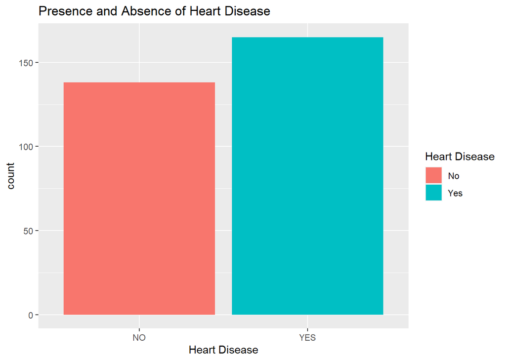

```r
library(ggplot2)
ggplot(data2,aes(x=target,fill=target))+
  geom_bar()+
  xlab("Heart Disease")+
  ylab("count")+
  ggtitle("Presence and Absence of Heart Disease")+
  scale_fill_discrete(name='Heart Disease',labels=c("No","Yes"))
```

* * *

Inference: It can be observed from the above graph that from the given dataset, more people are prone towards having a pathological disease and fewer number of patients are likely to escape from the same.

```r
prop.table(table(data2$target))
```

```
##
##        NO       YES
## 0.4554455 0.5445545
```

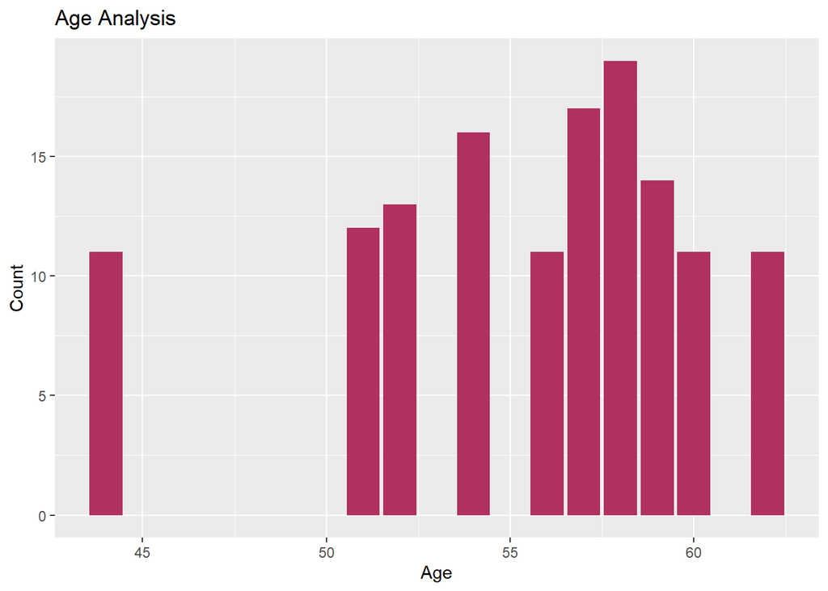

```r
#count the frequency of the values of age
data2%>%
  group_by(ï..age)%>%
  count()%>%
  filter(n>10)%>%
  ggplot()+
  geom_col(aes(ï..age,n),fill='maroon')+
  ggtitle("Age Analysis")+
  xlab("Age")+
  ylab("Count")
```

* * *

Inference: From this visualization it can be observed that majority of the people who have been considered in the dataset belong to the age group of 50 to 60.

## Compare BP across chest pain

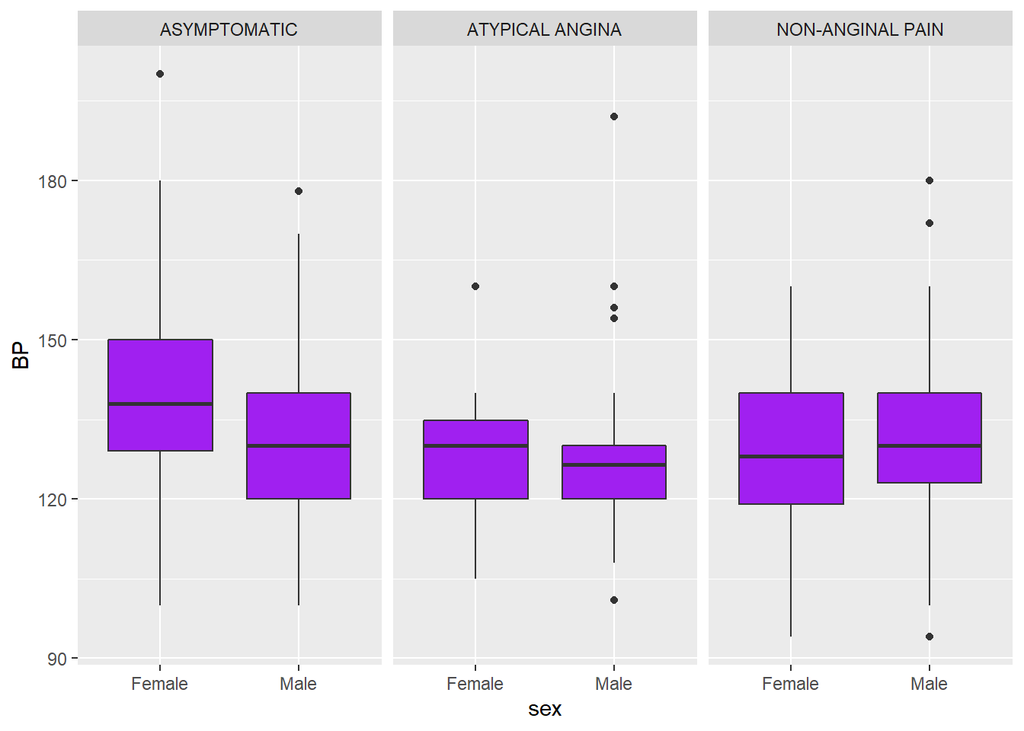

```r
data2%>%
  ggplot(aes(x=sex,y=trestbps))+
  geom_boxplot(fill='purple')+
  xlab('sex')+
  ylab('BP')+
  facet_grid(~cp)
```

Inference: The above given facet_wrapped box plot gives the various central dispersion techniques for the three types of chest pains with regards to blood pressure for both males and females. For asymptomatic chest pain, females are likely to have a higher BP when compared to male and the same can be observed for atypical angina chest pain also. However, in the non-anginal chest pain, males are likely to have a higher BP when compared to females.

## Comparing cholestrol across chest pain

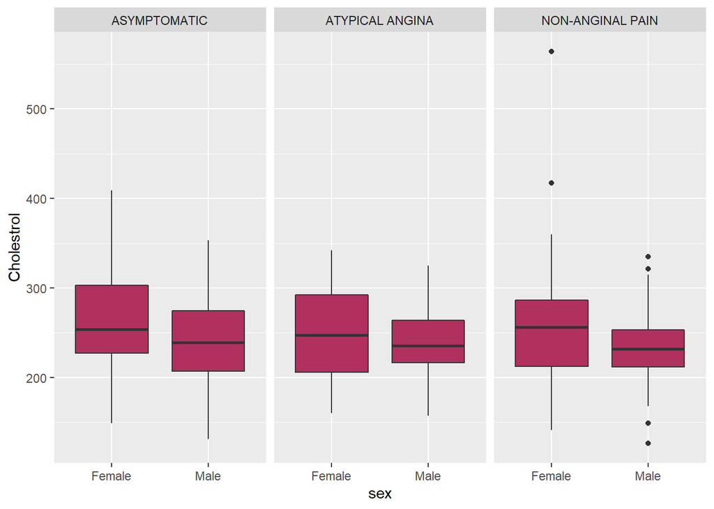

```r
data2%>%
  ggplot(aes(x=sex,y=chol))+
  geom_boxplot(fill='maroon')+
  xlab('sex')+
  ylab('Cholestrol')+
  facet_grid(~cp)
```

* * *

Inference: The above given facet_wrapped box plot gives the various central dispersion techniques for the three types of chest pains with regards to cholestrol for both males and females. For asymptomatic, atypical angina and non-anginal chest pain, females are likely to have a higher cholestrol level when compared to their male counterparts.

## Correlation Plot

```r
library(corrplot)
corheart <- cor(data2[,10:14])
corheart
```

```
##              ï..age    trestbps         chol      thalach     oldpeak
## ï..age    1.0000000  0.27935091  0.213677957 -0.398521938  0.21001257
## trestbps  0.2793509  1.00000000  0.123174207 -0.046697728  0.19321647
## chol      0.2136780  0.12317421  1.000000000 -0.009939839  0.05395192
## thalach  -0.3985219 -0.04669773 -0.009939839  1.000000000 -0.34418695
## oldpeak   0.2100126  0.19321647  0.053951920 -0.344186948  1.00000000
```

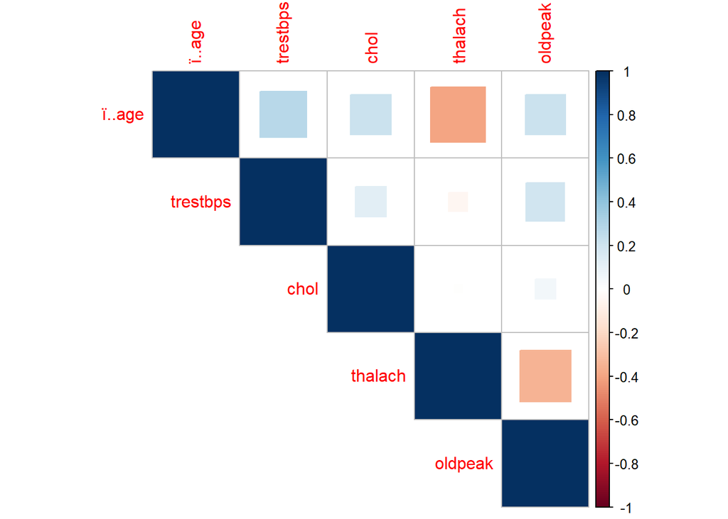

```r
corrplot(corheart,method='square',type='upper')
```

## Disease Prediction

```r
set.seed(2020, sample.kind = "Rounding")
# Divide into train and validation dataset
test_index <- createDataPartition(y = heart$target, times = 1, p = 0.2, list= FALSE)
train_set <- heart[-test_index, ]
validation <- heart[test_index, ]

# Converting the dependent variables to factors
train_set$target <- as.factor(train_set$target)
validation$target <- as.factor(validation$target)
```

## LDA

```r
lda_fit <- train(target ~ ., method = "lda", data = train_set)
lda_predict <- predict(lda_fit, validation)
confusionMatrix(lda_predict, validation$target)
```

```
## Confusion Matrix and Statistics
##
##           Reference
## Prediction  0  1
##          0 22  3
##          1  7 29
##
##                Accuracy : 0.8361
##                  95% CI : (0.7191, 0.9185)
##     No Information Rate : 0.5246
##     P-Value [Acc > NIR] : 3.442e-07
##
##                   Kappa : 0.6692
##
##  Mcnemar's Test P-Value : 0.3428
##
##             Sensitivity : 0.7586
##             Specificity : 0.9062
##          Pos Pred Value : 0.8800
##          Neg Pred Value : 0.8056
##              Prevalence : 0.4754
##          Detection Rate : 0.3607
##    Detection Prevalence : 0.4098
##       Balanced Accuracy : 0.8324
##
##        'Positive' Class : 0
##
```

## QDA

```r
qda_fit <- train(target ~ ., method = "qda", data = train_set)
qda_predict <- predict(qda_fit, validation)
confusionMatrix(qda_predict, validation$target)
```

```
## Confusion Matrix and Statistics
##
##           Reference
## Prediction  0  1
##          0 24  3
##          1  5 29
##
##                Accuracy : 0.8689
##                  95% CI : (0.7578, 0.9416)
##     No Information Rate : 0.5246
##     P-Value [Acc > NIR] : 1.292e-08
##
##                   Kappa : 0.7362
##
##  Mcnemar's Test P-Value : 0.7237
##
##             Sensitivity : 0.8276
##             Specificity : 0.9062
##          Pos Pred Value : 0.8889
##          Neg Pred Value : 0.8529
##              Prevalence : 0.4754
##          Detection Rate : 0.3934
##    Detection Prevalence : 0.4426
##       Balanced Accuracy : 0.8669
##
##        'Positive' Class : 0
##
```

Inference: Using QDA, the accuracy is 0.8689 which is pretty good and the specificity and sensitivity values are 0.9062 and 0.8276 which means the true negative and true positive rates are good enough.

## KNN Classifier

```r
ctrl <- trainControl(method = "cv", verboseIter = FALSE, number = 5)
knnFit <- train(target ~ .,
                data = train_set, method = "knn", preProcess = c("center","scale"),
                trControl = ctrl , tuneGrid = expand.grid(k = seq(1, 20, 2)))
```

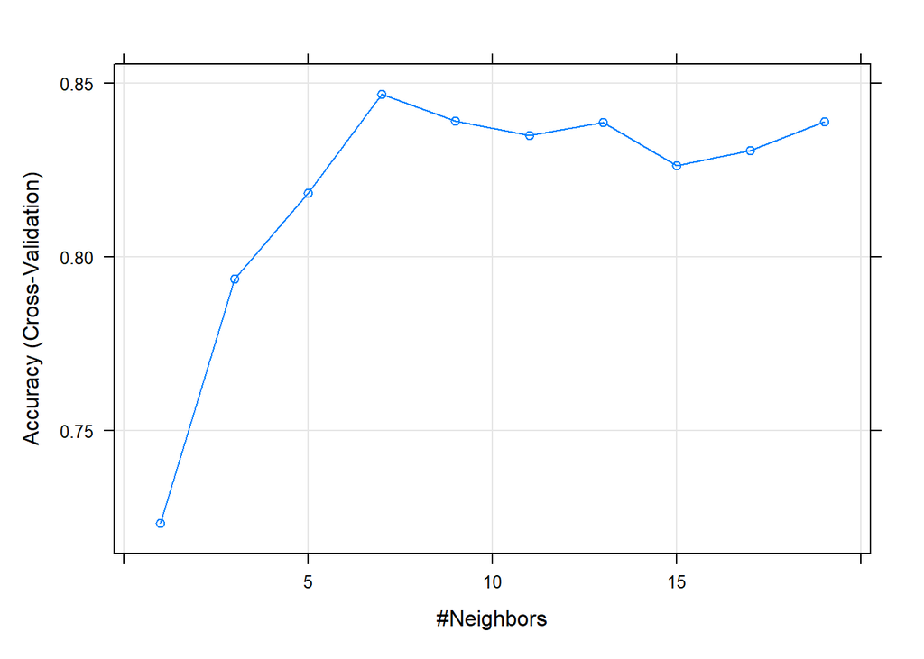

```r
plot(knnFit)
```

```r
toc()

knnPredict <- predict(knnFit,newdata = validation )
knn_results <- confusionMatrix(knnPredict, validation$target )

knn_results
```

```
## Confusion Matrix and Statistics
##
##           Reference
## Prediction  0  1
##          0 23  4
##          1  6 28
##
##                Accuracy : 0.8361
##                  95% CI : (0.7191, 0.9185)
##     No Information Rate : 0.5246
##     P-Value [Acc > NIR] : 3.442e-07
##
##                   Kappa : 0.6703
##
##  Mcnemar's Test P-Value : 0.7518
##
##             Sensitivity : 0.7931
##             Specificity : 0.8750
##          Pos Pred Value : 0.8519
##          Neg Pred Value : 0.8235
##              Prevalence : 0.4754
##          Detection Rate : 0.3770
##    Detection Prevalence : 0.4426
##       Balanced Accuracy : 0.8341
##
##        'Positive' Class : 0
##
```

Inference: Using KNN, the accuracy is 0.8361 which is pretty good and the specificity and sensitivity values are 0.8750 and 0.7931 which means the true negative and true positive rates are good enough.

## SVM

```r
ctrl <- trainControl(method = "cv", verboseIter = FALSE, number = 5)

grid_svm <- expand.grid(C = c(0.01, 0.1, 1, 10, 20))

tic(msg= " Total time for SVM :: ")
svm_fit <- train(target ~ .,data = train_set,
                 method = "svmLinear", preProcess = c("center","scale"),
                 tuneGrid = grid_svm, trControl = ctrl)
```

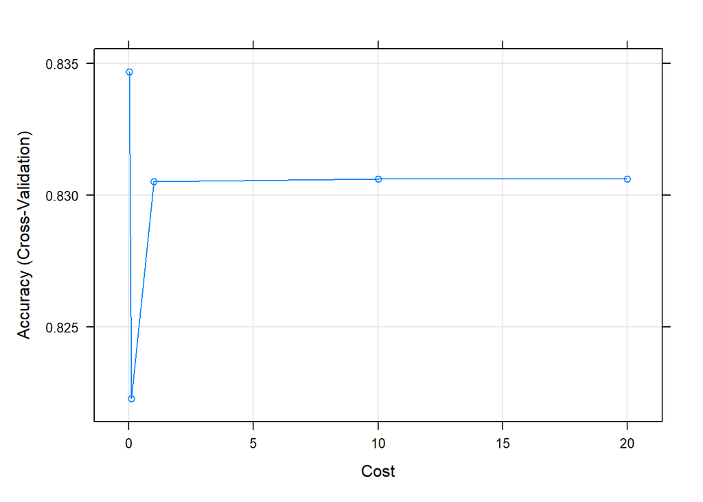

```r
plot(svm_fit)
```

```r
toc()
```

```
##  Total time for SVM :: : 1.95 sec elapsed
```

```r
svm_predict <- predict(svm_fit, newdata = validation)
svm_results <- confusionMatrix(svm_predict, validation$target)

svm_results
```

```
## Confusion Matrix and Statistics
##
##           Reference
## Prediction  0  1
##          0 21  2
##          1  8 30
##
##                Accuracy : 0.8361
##                  95% CI : (0.7191, 0.9185)
##     No Information Rate : 0.5246
##     P-Value [Acc > NIR] : 3.442e-07
##
##                   Kappa : 0.6681
##
##  Mcnemar's Test P-Value : 0.1138
##
##             Sensitivity : 0.7241
##             Specificity : 0.9375
##          Pos Pred Value : 0.9130
##          Neg Pred Value : 0.7895
##              Prevalence : 0.4754
##          Detection Rate : 0.3443
##    Detection Prevalence : 0.3770
##       Balanced Accuracy : 0.8308
##
##        'Positive' Class : 0
##
```

Inference: Using SVM, the accuracy is 0.8361 which is pretty good and the specificity and sensitivity values are 0.9375 and 0.7241 which means the true negative and true positive rates are good enough.

## Random Forest

```r
urlPackage <- "https://cran.r-project.org/src/contrib/Archive/randomForest/randomForest_4.6-12.tar.gz"
control<- trainControl(method = "cv", number = 5, verboseIter = FALSE)
grid <-data.frame(mtry = seq(1, 10, 2))
tic(msg= " Total time for rf :: ")
rf_fit <- train(target ~ ., method = "rf", data = train_set, ntree = 20, trControl = control,
                  tuneGrid = grid)
```

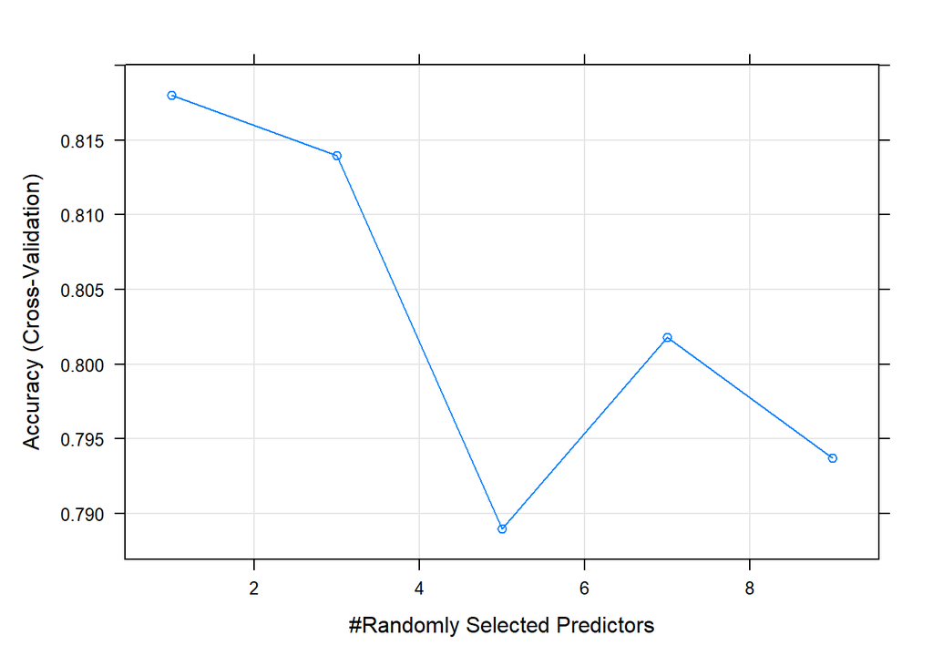

```r
plot(rf_fit)
```

```r
toc()
```

```
##  Total time for rf :: : 0.54 sec elapsed
```

```r
rf_predict <- predict(rf_fit, newdata = validation)

rf_results <- confusionMatrix(rf_predict, validation$target)

rf_results
```

```
## Confusion Matrix and Statistics
##
##           Reference
## Prediction  0  1
##          0 21  5
##          1  8 27
##
##                Accuracy : 0.7869
##                  95% CI : (0.6632, 0.8814)
##     No Information Rate : 0.5246
##     P-Value [Acc > NIR] : 2.064e-05
##
##                   Kappa : 0.5707
##
##  Mcnemar's Test P-Value : 0.5791
##
##             Sensitivity : 0.7241
##             Specificity : 0.8438
##          Pos Pred Value : 0.8077
##          Neg Pred Value : 0.7714
##              Prevalence : 0.4754
##          Detection Rate : 0.3443
##    Detection Prevalence : 0.4262
##       Balanced Accuracy : 0.7839
##
##        'Positive' Class : 0
##
```

Inference: Using RandomForest, the accuracy is 0.7869 which is pretty good and the specificity and sensitivity values are 0.8438 and 0.7241 which means the true negative and true positive rates are good enough.

## GBM

```r
gbmGrid <-  expand.grid(interaction.depth = c(1, 5, 10, 25, 30),
                        n.trees = c(5, 10, 25, 50),
                        shrinkage = c(0.1, 0.2, 0.3,  0.4, 0.5),
                        n.minobsinnode = 20)

tic(msg= " Total time for GBM :: ")
gbm_fit <- train(target ~ ., method = "gbm", data = train_set,  trControl = control, verbose = FALSE,
                   tuneGrid = gbmGrid)
```

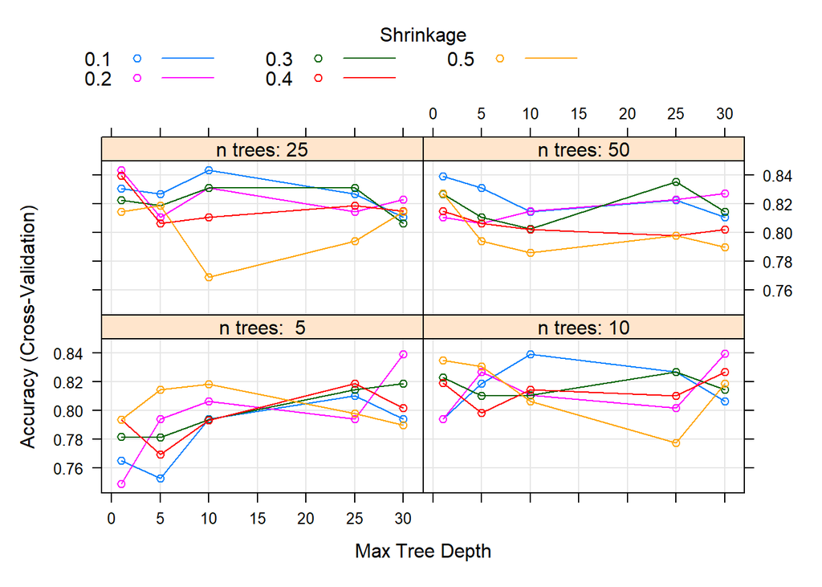

```r
plot(gbm_fit)
```

```r
toc()
```

```
##  Total time for GBM :: : 3.04 sec elapsed
```

```r
gbm_predict <- predict(gbm_fit, newdata = validation)

gbm_results <- confusionMatrix(gbm_predict, validation$target)

gbm_results
```

```
## Confusion Matrix and Statistics
##
##           Reference
## Prediction  0  1
##          0 22  5
##          1  7 27
##
##                Accuracy : 0.8033
##                  95% CI : (0.6816, 0.894)
##     No Information Rate : 0.5246
##     P-Value [Acc > NIR] : 5.828e-06
##
##                   Kappa : 0.6043
##
##  Mcnemar's Test P-Value : 0.7728
##
##             Sensitivity : 0.7586
##             Specificity : 0.8438
##          Pos Pred Value : 0.8148
##          Neg Pred Value : 0.7941
##              Prevalence : 0.4754
##          Detection Rate : 0.3607
##    Detection Prevalence : 0.4426
##       Balanced Accuracy : 0.8012
##
##        'Positive' Class : 0
##
```

Inference: Using GBM, the accuracy is 0.8033 which is pretty good and the specificity and sensitivity values are 0.8438 and 0.7586 which means the true negative and true positive rates are good enough.